# 🚢 Titanic — historia przetrwania zaklęta w liczbach

## O Danych

Dane o pasażerach Titanica

Zbiór danych zawiera informacje o pasażerach RMS Titanic, który zatonął 15 kwietnia 1912 roku po zderzeniu z górą lodową. Dane obejmują takie atrybuty jak klasa podróży, wiek, płeć, liczba rodzeństwa/małżonków na pokładzie, liczba rodziców/dzieci na pokładzie, cena biletu oraz miejsce zaokrętowania.

Zbiór zawiera także informację o tym, czy pasażer przeżył katastrofę.

Titanic przewoził ponad 2,200 osób, z czego ponad 1,500 zginęło, co czyni tę katastrofę jedną z najbardziej tragicznych w historii morskiej.

[figure not shown]

### Kolumny:

- **pclass** - Klasa biletu
- **survived** - Czy pasażer przeżył katastrofę
- **name** - Imię i nazwisko pasażera
- **sex** - Płeć pasażera
- **age** - Wiek pasażera
- **sibsp** - Liczba rodzeństwa/małżonków na pokładzie
- **parch** - Liczba rodziców/dzieci na pokładzie
- **ticket** - Numer biletu
- **fare** - Cena biletu
- **cabin** - Numer kabiny
- **embarked** - Port, w którym pasażer wszedł na pokład (C = Cherbourg, Q = Queenstown, S = Southampton)
- **boat** - Numer łodzi ratunkowej
- **body** - Numer ciała (jeśli pasażer nie przeżył i ciało zostało odnalezione)
- **home.dest** - Miejsce docelowe

# Eksploracyjna analiza danych

Będziemy analizować dane dotyczące katastrofy Titanica.

[figure not shown]

## Krok 1 - Ogólny przegląd danych

|  | pclass | survived | name | sex | age | sibsp | parch | ticket | fare | cabin | embarked | boat | body | home.dest |
| --- | --- | --- | --- | --- | --- | --- | --- | --- | --- | --- | --- | --- | --- | --- |
| 0 | 1.0 | 1.0 | Allen, Miss. Elisabeth Walton | female | 29.0000 | 0.0 | 0.0 | 24160 | 211.3375 | B5 | S | 2 | NaN | St Louis, MO |
| 1 | 1.0 | 1.0 | Allison, Master. Hudson Trevor | male | 0.9167 | 1.0 | 2.0 | 113781 | 151.5500 | C22 C26 | S | 11 | NaN | Montreal, PQ / Chesterville, ON |
| 2 | 1.0 | 0.0 | Allison, Miss. Helen Loraine | female | 2.0000 | 1.0 | 2.0 | 113781 | 151.5500 | C22 C26 | S | NaN | NaN | Montreal, PQ / Chesterville, ON |
| 3 | 1.0 | 0.0 | Allison, Mr. Hudson Joshua Creighton | male | 30.0000 | 1.0 | 2.0 | 113781 | 151.5500 | C22 C26 | S | NaN | 135.0 | Montreal, PQ / Chesterville, ON |
| 4 | 1.0 | 0.0 | Allison, Mrs. Hudson J C (Bessie Waldo Daniels) | female | 25.0000 | 1.0 | 2.0 | 113781 | 151.5500 | C22 C26 | S | NaN | NaN | Montreal, PQ / Chesterville, ON |
| ... | ... | ... | ... | ... | ... | ... | ... | ... | ... | ... | ... | ... | ... | ... |
| 1305 | 3.0 | 0.0 | Zabour, Miss. Thamine | female | NaN | 1.0 | 0.0 | 2665 | 14.4542 | NaN | C | NaN | NaN | NaN |
| 1306 | 3.0 | 0.0 | Zakarian, Mr. Mapriededer | male | 26.5000 | 0.0 | 0.0 | 2656 | 7.2250 | NaN | C | NaN | 304.0 | NaN |
| 1307 | 3.0 | 0.0 | Zakarian, Mr. Ortin | male | 27.0000 | 0.0 | 0.0 | 2670 | 7.2250 | NaN | C | NaN | NaN | NaN |
| 1308 | 3.0 | 0.0 | Zimmerman, Mr. Leo | male | 29.0000 | 0.0 | 0.0 | 315082 | 7.8750 | NaN | S | NaN | NaN | NaN |
| 1309 | NaN | NaN | NaN | NaN | NaN | NaN | NaN | NaN | NaN | NaN | NaN | NaN | NaN | NaN |

1310 rows × 14 columns

### Pokazujemy 10 losowych rekordów.

|  | pclass | survived | name | sex | age | sibsp | parch | ticket | fare | cabin | embarked | boat | body | home.dest |
| --- | --- | --- | --- | --- | --- | --- | --- | --- | --- | --- | --- | --- | --- | --- |
| 697 | 3.0 | 0.0 | Cacic, Miss. Marija | female | 30.0 | 0.0 | 0.0 | 315084 | 8.6625 | NaN | S | NaN | NaN | NaN |
| 1030 | 3.0 | 0.0 | Moran, Mr. James | male | NaN | 0.0 | 0.0 | 330877 | 8.4583 | NaN | Q | NaN | NaN | NaN |
| 605 | 3.0 | 1.0 | Abelseth, Mr. Olaus Jorgensen | male | 25.0 | 0.0 | 0.0 | 348122 | 7.6500 | F G63 | S | A | NaN | Perkins County, SD |
| 841 | 3.0 | 0.0 | Hagardon, Miss. Kate | female | 17.0 | 0.0 | 0.0 | AQ/3. 30631 | 7.7333 | NaN | Q | NaN | NaN | NaN |
| 1077 | 3.0 | 1.0 | O'Driscoll, Miss. Bridget | female | NaN | 0.0 | 0.0 | 14311 | 7.7500 | NaN | Q | D | NaN | NaN |
| 815 | 3.0 | 0.0 | Garfirth, Mr. John | male | NaN | 0.0 | 0.0 | 358585 | 14.5000 | NaN | S | NaN | NaN | NaN |
| 93 | 1.0 | 1.0 | Dodge, Dr. Washington | male | 53.0 | 1.0 | 1.0 | 33638 | 81.8583 | A34 | S | 13 | NaN | San Francisco, CA |
| 1217 | 3.0 | 0.0 | Soholt, Mr. Peter Andreas Lauritz Andersen | male | 19.0 | 0.0 | 0.0 | 348124 | 7.6500 | F G73 | S | NaN | NaN | NaN |
| 833 | 3.0 | 0.0 | Green, Mr. George Henry | male | 51.0 | 0.0 | 0.0 | 21440 | 8.0500 | NaN | S | NaN | NaN | Dorking, Surrey, England |
| 199 | 1.0 | 1.0 | Mayne, Mlle. Berthe Antonine ("Mrs de Villiers") | female | 24.0 | 0.0 | 0.0 | PC 17482 | 49.5042 | C90 | C | 6 | NaN | Belgium Montreal, PQ |

### Informacje o kolumnach

```
<class 'pandas.core.frame.DataFrame'>
RangeIndex: 1310 entries, 0 to 1309
Data columns (total 14 columns):
 #   Column     Non-Null Count  Dtype
---  ------     --------------  -----
 0   pclass     1309 non-null   float64
 1   survived   1309 non-null   float64
 2   name       1309 non-null   object
 3   sex        1309 non-null   object
 4   age        1046 non-null   float64
 5   sibsp      1309 non-null   float64
 6   parch      1309 non-null   float64
 7   ticket     1309 non-null   object
 8   fare       1308 non-null   float64
 9   cabin      295 non-null    object
 10  embarked   1307 non-null   object
 11  boat       486 non-null    object
 12  body       121 non-null    float64
 13  home.dest  745 non-null    object
dtypes: float64(7), object(7)
memory usage: 143.4+ KB
```

### Podstawowe statystyki dla kolumn numerycznych

|  | pclass | survived | age | sibsp | parch | fare | body |
| --- | --- | --- | --- | --- | --- | --- | --- |
| count | 1309.00 | 1309.00 | 1046.00 | 1309.00 | 1309.00 | 1308.00 | 121.00 |
| mean | 2.29 | 0.38 | 29.88 | 0.50 | 0.39 | 33.30 | 160.81 |
| std | 0.84 | 0.49 | 14.41 | 1.04 | 0.87 | 51.76 | 97.70 |
| min | 1.00 | 0.00 | 0.17 | 0.00 | 0.00 | 0.00 | 1.00 |
| 25% | 2.00 | 0.00 | 21.00 | 0.00 | 0.00 | 7.90 | 72.00 |
| 50% | 3.00 | 0.00 | 28.00 | 0.00 | 0.00 | 14.45 | 155.00 |
| 75% | 3.00 | 1.00 | 39.00 | 1.00 | 0.00 | 31.28 | 256.00 |
| max | 3.00 | 1.00 | 80.00 | 8.00 | 9.00 | 512.33 | 328.00 |

### Wartości unikatowe w kolumnie

```
pclass          3
survived        2
name         1307
sex             2
age            98
sibsp           7
parch           8
ticket        929
fare          281
cabin         186
embarked        3
boat           27
body          121
home.dest     369
dtype: int64
```

### Płeć - rozkład liczbowy

| sex | count |
| --- | --- |
| male | 843 |
| female | 466 |

### Klasa biletu - rozkład liczbowy

| pclass | count |
| --- | --- |
| 3.0 | 709 |
| 1.0 | 323 |
| 2.0 | 277 |

### Czy pasażer przeżył? - rozkład liczbowy

| survived | count |
| --- | --- |
| 0.0 | 809 |
| 1.0 | 500 |

### Port, w którym pasażer rozpoczął podróż - rozkład liczbowy

| embarked | count |
| --- | --- |
| Southampton | 914 |
| Cherbourg | 270 |
| Queenstown | 123 |

### Wnioski

Do analizy danych posłuży nam **1310** rekordów oraz **14** kolumn. 7 kolumn zawiera dane liczbowe oraz 7 kolumn zawiera tekst.

Po wstępnym przeglądzie danych mamy informacje na temat:

1. podziału płci pasażerów - **843** mężczyzn oraz **466** kobiet
2. klasy biletu - **323** - klasa 1, **277** - klasa 2, **709** - klasa 3
3. ilości zgonów (**809**) i osób, które przeżyły (**500**)
4. Liczby osób, które wsiadły na pokład w 3 różnych portach:
   - **914** Southampton
   - **270** Cherbourg
   - **123** Queenstown

Ostatni rząd nie zawiera jakichkolwiek danych i w następnym kroku zostanie usunięty.

## Krok 2 - Analiza brakujących wartości

### Rozkład brakujących wartości

```
pclass          1
survived        1
name            1
sex             1
age           264
sibsp           1
parch           1
ticket          1
fare            2
cabin        1015
embarked        3
boat          824
body         1189
home.dest     565
dtype: int64
```

### Usunęliśmy ostatni wers, gdyż nie zawiera żadnych danych.

#### Oraz kolumny, takie jak: cabin, body, boat, home.dest - w przeważającej większości brakuje w nich danych nie posłużą nam do analizy

### Sprawdzamy czy są jakieś zduplikowane dane

```
0
```

### Zmieniamy nazwy kolumn na bardziej przyjazne

|  | klasa biletu | Ocalał | imię i nazwisko | płeć | wiek | rodz/małż | rodzic/dzieci | numer biletu | cena biletu | Port |
| --- | --- | --- | --- | --- | --- | --- | --- | --- | --- | --- |
| 0 | 1.0 | 1.0 | Allen, Miss. Elisabeth Walton | female | 29.0000 | 0.0 | 0.0 | 24160 | 211.3375 | S |
| 1 | 1.0 | 1.0 | Allison, Master. Hudson Trevor | male | 0.9167 | 1.0 | 2.0 | 113781 | 151.5500 | S |
| 2 | 1.0 | 0.0 | Allison, Miss. Helen Loraine | female | 2.0000 | 1.0 | 2.0 | 113781 | 151.5500 | S |
| 3 | 1.0 | 0.0 | Allison, Mr. Hudson Joshua Creighton | male | 30.0000 | 1.0 | 2.0 | 113781 | 151.5500 | S |
| 4 | 1.0 | 0.0 | Allison, Mrs. Hudson J C (Bessie Waldo Daniels) | female | 25.0000 | 1.0 | 2.0 | 113781 | 151.5500 | S |
| ... | ... | ... | ... | ... | ... | ... | ... | ... | ... | ... |
| 1304 | 3.0 | 0.0 | Zabour, Miss. Hileni | female | 14.5000 | 1.0 | 0.0 | 2665 | 14.4542 | C |
| 1305 | 3.0 | 0.0 | Zabour, Miss. Thamine | female | NaN | 1.0 | 0.0 | 2665 | 14.4542 | C |
| 1306 | 3.0 | 0.0 | Zakarian, Mr. Mapriededer | male | 26.5000 | 0.0 | 0.0 | 2656 | 7.2250 | C |
| 1307 | 3.0 | 0.0 | Zakarian, Mr. Ortin | male | 27.0000 | 0.0 | 0.0 | 2670 | 7.2250 | C |
| 1308 | 3.0 | 0.0 | Zimmerman, Mr. Leo | male | 29.0000 | 0.0 | 0.0 | 315082 | 7.8750 | S |

1309 rows × 10 columns

### Tak się prezentuje rozkład liczbowy brakujących wartości, który posłuży nam do dalszej analizy

```
klasa biletu       0
Ocalał             0
imię i nazwisko    0
płeć               0
wiek               0
rodz/małż          0
rodzic/dzieci      0
numer biletu       0
cena biletu        1
Port               2
dtype: int64
```

### Wnioski

1. Usunęliśmy ostatni wiersz, gdyż nie było w nim żadnych danych.
2. Usunęliśmy kolumny dotyczące numeru kabiny, numeru ciała, łodzi ratunkowej oraz miejsca docelowego - nie posłużą nam do analizy.
3. Nie mamy żadnych zduplikowanych wierszy.
4. Zamieniliśmy nazwy kolumn na polskie nazwy.
5. W kolumnie dotyczącej wieku - brakujące wartości wypełniliśmy średnią.

## Krok 3 - Analiza pojedyńczych zmiennych

### Między młodością a dojrzałością – wiek pasażerów na Titanicu

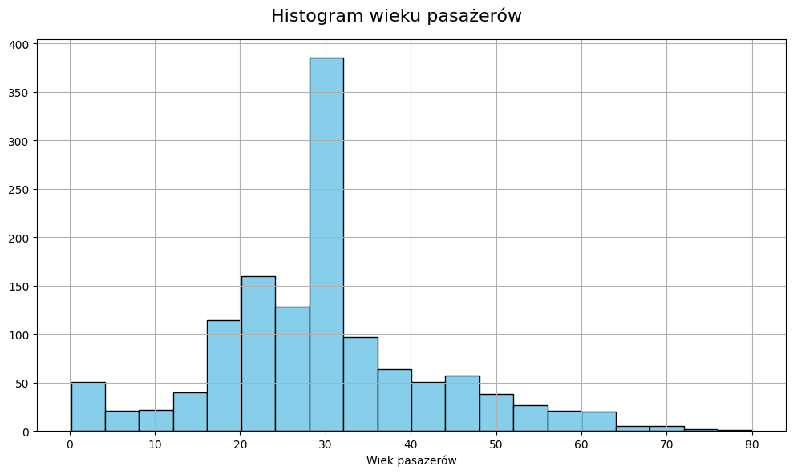

### Pod pokładem czy na salonach? Co mówią bilety?

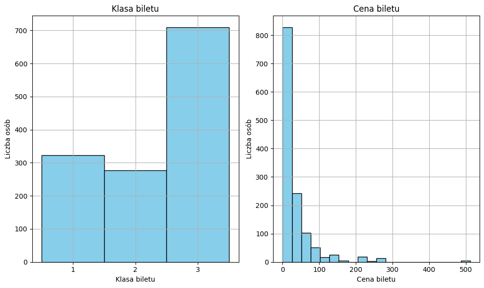

### Titanic: podróż z rodziną czy samotna droga?

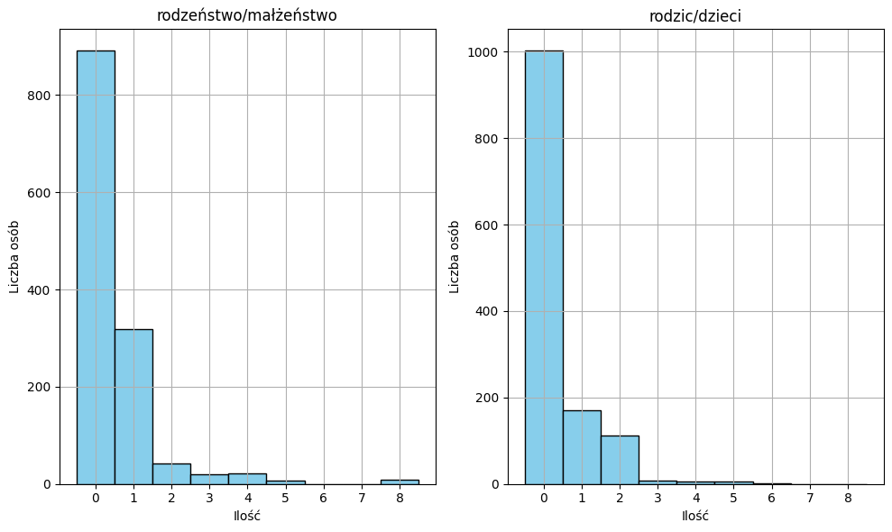

### Struktura płci pasażerów na Titanicu

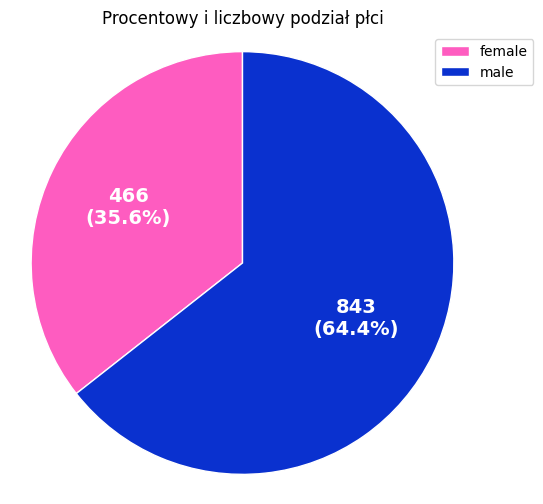

### Losy pasażerów: ocalałych i tych, którzy nie przeżyli

#### Zielony znaczy życie, czerwony – tragedię

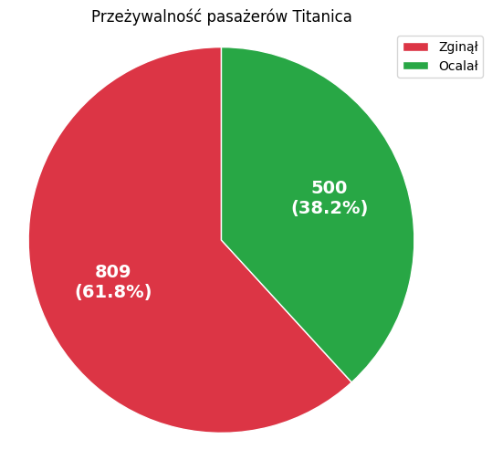

### Statystyka życia i śmierci: Titanic w liczbach

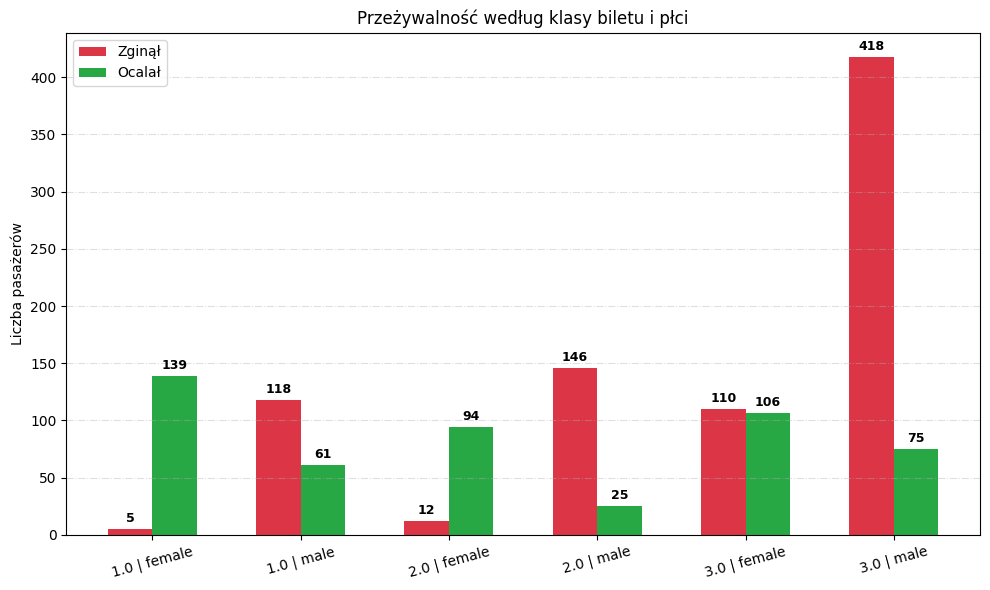

### Wpływ klasy biletu i płci na przeżywalność pasażerów Titanica

| klasa biletu | płeć | Ilość pasażerów | Ilość ocalonych |
| --- | --- | --- | --- |
| 1.0 | female | 144 | 139 |
|  | male | 179 | 61 |
| 2.0 | female | 106 | 94 |
|  | male | 171 | 25 |
| 3.0 | female | 216 | 106 |
|  | male | 493 | 75 |

### Kto przeżył, a kto nie? Zobacz proporcje

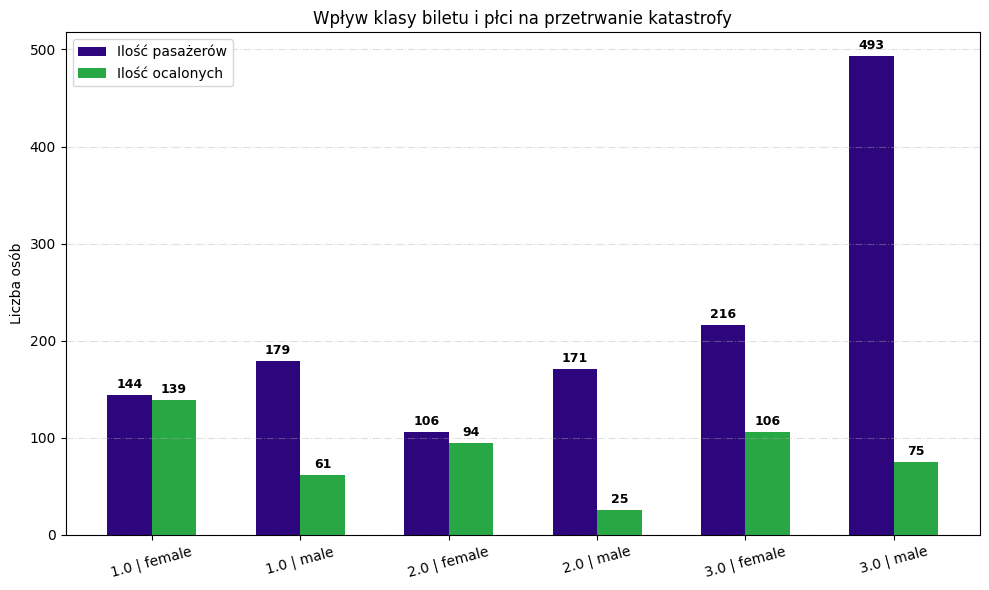

### Sprawdźmy jak to wygląda u pasażerów poniżej 18 roku życia

| klasa biletu | płeć | Ilość dzieci | Ilość ocalonych dzieci |
| --- | --- | --- | --- |
| 1.0 | female | 8 | 7 |
|  | male | 7 | 6 |
| 2.0 | female | 18 | 18 |
|  | male | 15 | 11 |
| 3.0 | female | 46 | 25 |
|  | male | 60 | 14 |

### Za młodzi, by decydować — ale ich przeżycie zależało od klasy i płci

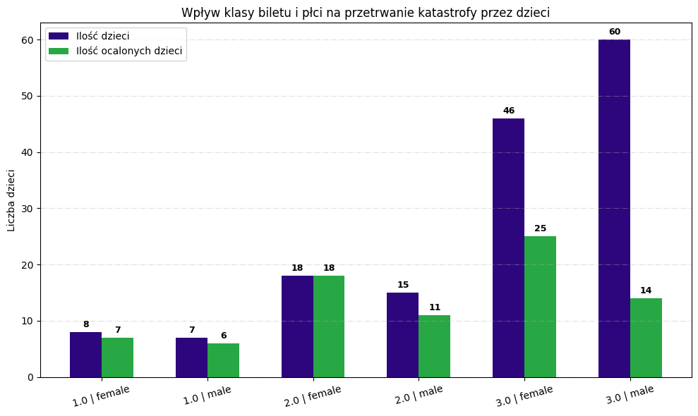

### Wnioski

Z danych, które posłużyły nam do analizy dowiadujemy się, że:

1. Na pokładzie było **466** kobiet i **843** mężczyzn. Wśród nich **154** dzieci poniżej 18 roku życia.
2. Przeważająca ilość pasażerów to ludzie młodzi między 20-40 rokiem życia.
3. Zdecydowana większość pasażerów podróżowała samotnie (bez żony/dzieci lub byli singlami).
4. Zauważamy, że kobiety oraz dzieci podróżujące klasą 1 lub 2 w większości udalo się ocalić.
5. Jako ciekawostkę można dodać iż zarówno najstarszy mężczyzna (80lat) oraz kobieta (76lat) przeżyli katastrofę.

## Krok 4 - Analiza relacji między zmiennymi

### Wzajemne relacje zmiennych liczbowych w grupie dorosłych pasażerów

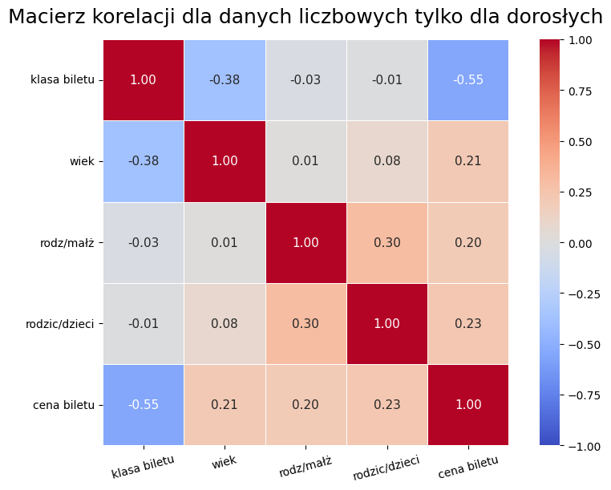

### Odkrywamy relacje między zmiennymi liczbowymi wśród dzieci

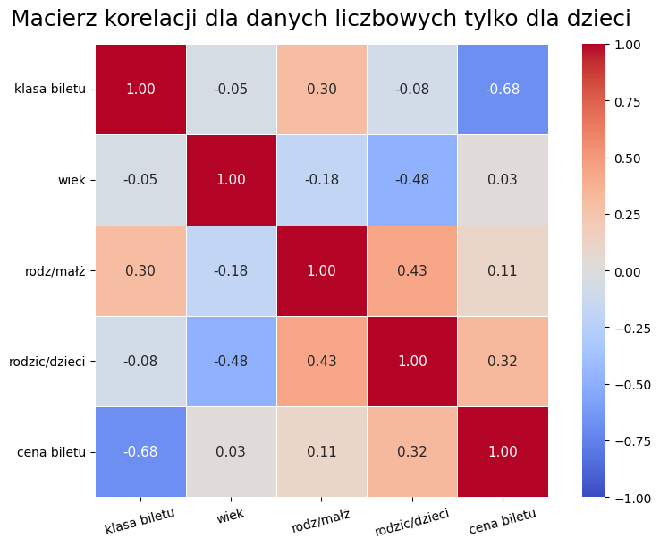

### Co łączy wiek, klasę biletu i rodzinę? Macierz korelacji dla całej załogi

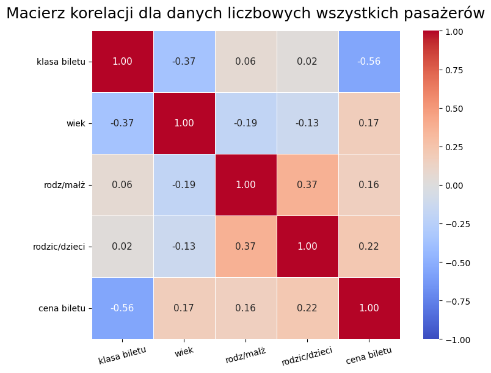

## Krok 5 - Analiza wartości odstających

### Wiek pasażerów Titanica — odkrywamy wartości odstające

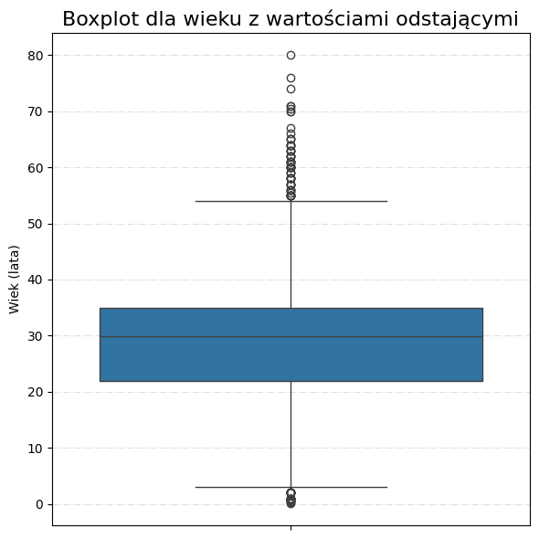

### Wiek dorosłych pasażerów – analiza rozrzutu

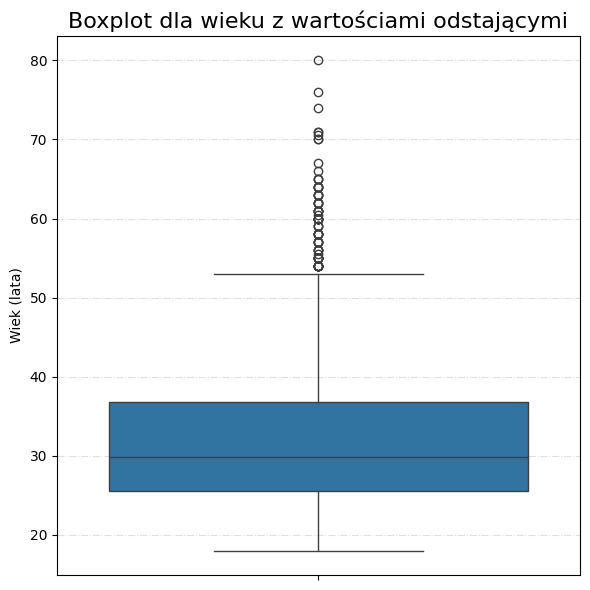

### Samotna podróż czy z rodziną? Analiza dorosłych pasażerów

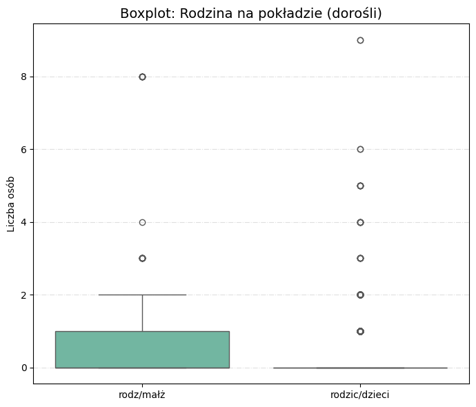

### Dzieci na Titanicu – same czy z rodziną?

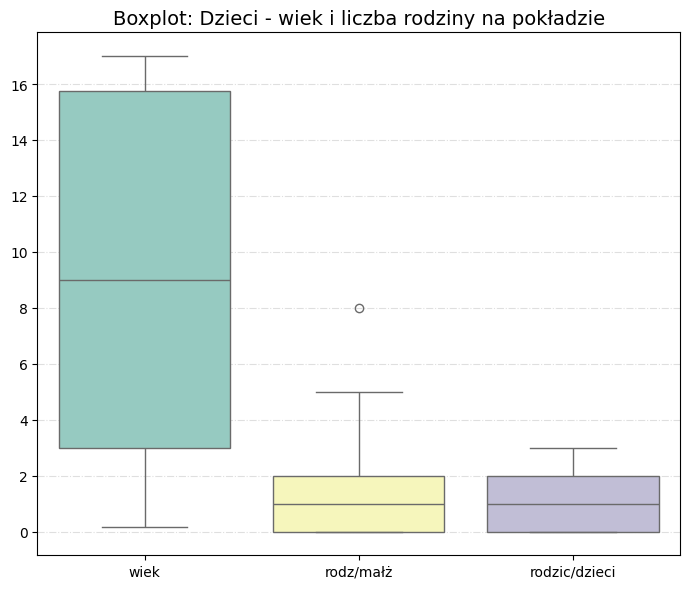

## Podsumowanie

Dokonaliśmy analizy danych. Uzyskaliśmy informację na temat:

1. podziału płci pasażerów - **843** mężczyzn oraz **466** kobiet
2. klasy biletu - **323** - klasa 1, **277** - klasa 2, **709** - klasa 3
3. ilości zgonów (**809**) i osób, które przeżyły (**500**)
4. Liczby osób, które wsiadły na pokład w 3 różnych portach:
   - **914** Southampton
   - **270** Cherbourg
   - **123** Queenstown
5. Zdecydowana większość pasażerów podróżowała samotnie (bez żony/dzieci lub byli singlami).
6. Większość pasażerów to ludzie młodzi między 20-40 rokiem życia.
7. Na pokładzie było **154** dzieci poniżej 18 roku życia.
8. Zauważamy, że kobiety podróżujące klasą 1 lub 2 w większości udalo się ocalić:
   - 139 z 144 kobiet z klasy 1 z czego 7 na 8 dziewcząt
   - 94 z 106 kobiet z klasy 2 z czego 18 na 18 dziewcząt
   - 106 z 216 kobiet z klasy 3 z czego 25 z 46 dziewcząt
9. Mężczyźni i chłopcy:
   - 61 z 179 (klasa 1) z czego 6 z 7 chłopców
   - 25 z 171 (klasa 2) z czego 11 z 15 chłopców
   - 75 z 493 (klasa 3) z czego 14 z 60 chłopców

#### Kobiety oraz dzieci, które miały wykupiony rejs w klasie 1 lub 2 w większości przeżyły katastrofę.

#### Dane pokazują wyraźne różnice społeczne i demograficzne, które miały wpływ na losy pasażerów.

[figure not shown]